# Biostat 203B Homework 3

Due Feb 23 @ 11:59PM

Author

106332516, Yue Shu

Load necessary libraries (you can add more as needed).

```r
library(readr)
library(dplyr)
library(arrow)
library(gtsummary)
library(memuse)
library(pryr)
library(R.utils)
library(tidyverse)
```

Display your machine memory.

```r
memuse::Sys.meminfo()
```

```
Totalram:  31.337 GiB
Freeram:   30.551 GiB
```

In this exercise, we use tidyverse (ggplot2, dplyr, etc) to explore the [MIMIC-IV](https://mimic.mit.edu/docs/iv/) data introduced in [homework 1](https://ucla-biostat-203b.github.io/2024winter/hw/hw1/hw1.html) and to build a cohort of ICU stays.

## Q1. Visualizing patient trajectory

Visualizing a patient’s encounters in a health care system is a common task in clinical data analysis. In this question, we will visualize a patient’s ADT (admission-discharge-transfer) history and ICU vitals in the MIMIC-IV data.

### Q1.1 ADT history

A patient’s ADT history records the time of admission, discharge, and transfer in the hospital. This figure shows the ADT history of the patient with `subject_id` 10001217 in the MIMIC-IV data. The x-axis is the calendar time, and the y-axis is the type of event (ADT, lab, procedure). The color of the line segment represents the care unit. The size of the line segment represents whether the care unit is an ICU/CCU. The crosses represent lab events, and the shape of the dots represents the type of procedure. The title of the figure shows the patient’s demographic information and the subtitle shows top 3 diagnoses.

[figure not shown]

Do a similar visualization for the patient with `subject_id` 10013310 using ggplot.

Hint: We need to pull information from data files `patients.csv.gz`, `admissions.csv.gz`, `transfers.csv.gz`, `labevents.csv.gz`, `procedures_icd.csv.gz`, `diagnoses_icd.csv.gz`, `d_icd_procedures.csv.gz`, and `d_icd_diagnoses.csv.gz`. For the big file `labevents.csv.gz`, use the Parquet format you generated in Homework 2. For reproducibility, make the Parquet folder `labevents_pq` available at the current working directory `hw3`, for example, by a symbolic link. Make your code reproducible.

**Answer:**

```r
# read in the data
patients <- read_csv("~/mimic/hosp/patients.csv.gz")%>%
  filter(subject_id == 10013310)
admissions <- read_csv("~/mimic/hosp/admissions.csv.gz")%>%
  filter(subject_id == 10013310)%>%
  mutate(admittime = as.POSIXct(admittime),dischtime = as.POSIXct(dischtime))
transfers <- read_csv("~/mimic/hosp/transfers.csv.gz")%>%
  filter(subject_id == 10013310)%>%
  mutate(intime = as.POSIXct(intime),outtime = as.POSIXct(outtime))
labevents <- read_parquet("~/labevents.parquet/part-0.parquet")%>%
  filter(subject_id == 10013310)%>%
  mutate(charttime = as.POSIXct(charttime))

procedures_icd <- read_csv("~/mimic/hosp/procedures_icd.csv.gz")%>%
  filter(subject_id == 10013310)%>%
  mutate(chartdate = as.POSIXct(chartdate))%>%
  left_join(read_csv("~/mimic/hosp/d_icd_procedures.csv.gz")%>%
            select(icd_code,long_title),by=("icd_code"))%>%
  collect()
diagnoses_icd <- read_csv("~/mimic/hosp/diagnoses_icd.csv.gz")%>%
  left_join(read_csv("~/mimic/hosp/d_icd_diagnoses.csv.gz"))%>%
  filter(subject_id==10013310)%>%
  collect()
transfers <- transfers %>%
  filter(eventtype != "discharge")

top_diagnoses <- diagnoses_icd %>%
  arrange(seq_num) %>%
  distinct(long_title, .keep_all = TRUE) %>%
  slice_head(n = 3) %>%
  pull(long_title) %>%
  paste(collapse = "\n")

patient_title <- paste("Patient 10013310",
                       ", ", patients$gender,
                       ", ", patients$anchor_age,
                       " years old, ", tolower(admissions$race), sep = "")
```

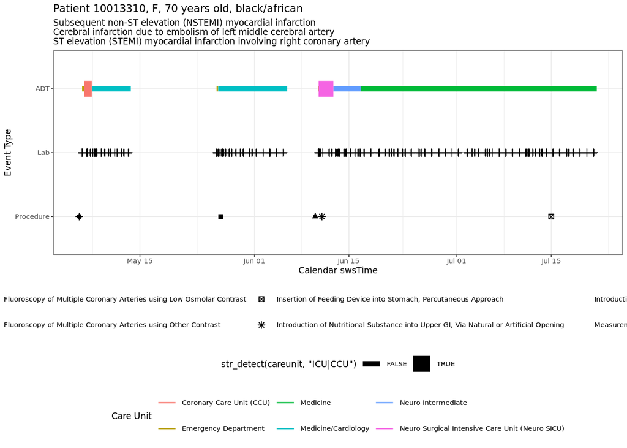

```r
ggplot() +
  geom_segment(data =  transfers, aes(x = intime, xend = outtime,
                                   y = "ADT", yend = "ADT",
                                   color = careunit,
               linewidth= str_detect(careunit, "ICU|CCU"))) +
  geom_point(data = procedures_icd, aes(x = chartdate, y = "Procedure", shape=long_title)) +
  geom_point(data = labevents, aes(x = charttime, y = "Lab"),
              shape = 3) +
  theme_bw(base_size = 7) +
  theme(legend.position = "bottom", legend.box = "vertical") +
  scale_y_discrete(limits = c("Procedure", "Lab", "ADT")) +
  labs(title = patient_title, subtitle = top_diagnoses,
       x = "Calendar swsTime", y = "Event Type", color = "Care Unit")
```

### Q1.2 ICU stays

ICU stays are a subset of ADT history. This figure shows the vitals of the patient `10001217` during ICU stays. The x-axis is the calendar time, and the y-axis is the value of the vital. The color of the line represents the type of vital. The facet grid shows the abbreviation of the vital and the stay ID.

[figure not shown]

Do a similar visualization for the patient `10013310`.

**Answer:**

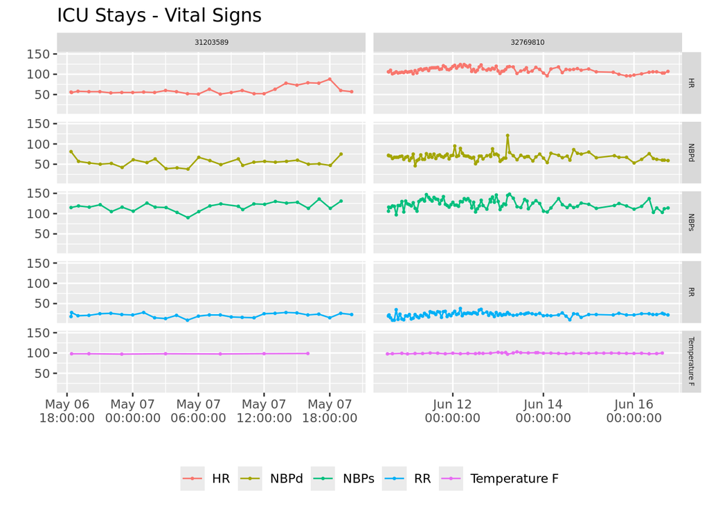

```r
library(data.table)
chartevents_tble1 <- arrow::open_dataset("~/chartevents.parquet", format = "parquet") %>%
  filter(subject_id ==10013310) %>%
  collect()

icustays_tble1 <- read_csv("~/mimic/icu/icustays.csv.gz")
icustays_tble1 <- icustays_tble1 %>%
  mutate(subject_id == 10013310)

chartevents_tble1 <- chartevents_tble1 %>%
  mutate(subject_id = 10013310)

# Join chartevents with icustays
chartevents_icustays <- chartevents_tble1 %>%
  inner_join(icustays_tble1, by = c("subject_id", "hadm_id", "stay_id"))


# Read item information from a CSV file
cht <- fread("~/mimic/icu/d_items.csv.gz", select = c("itemid", "abbreviation"))

# Join item information with chart events
chartevents_icustays <- merge(chartevents_icustays, cht, by = "itemid", all.x = TRUE)

# Filter vital signs
vital_signs <- c("HR", "NBPd", "NBPs", "RR", "Temperature F")
# Filter rows in chartevents_icustays based on 'abbreviation' column
chartevents_icustays <- chartevents_icustays[chartevents_icustays$abbreviation %in% vital_signs, ]

# Plot vital sign data
ggplot(data = chartevents_icustays , aes(x = charttime, y = as.numeric(value), color = abbreviation)) +
  geom_line() +
  geom_point(size = 0.5) +
  facet_grid(abbreviation ~ stay_id, scales = "free_x", space = "free_y") +
  labs(
    x = "",
    y = "",
    title = "ICU Stays - Vital Signs",
    color = "Vital Sign"
  ) +
  theme(
    legend.title = element_blank(),
    legend.position = "bottom",
    strip.text = element_text(size = 5)
  ) +
  scale_x_datetime(labels = scales::date_format("%b %d\n%H:%M:%S"))
```

## Q2. ICU stays

`icustays.csv.gz` (https://mimic.mit.edu/docs/iv/modules/icu/icustays/) contains data about Intensive Care Units (ICU) stays. The first 10 lines are

```bash
zcat < ~/mimic/icu/icustays.csv.gz | head
```

```
subject_id,hadm_id,stay_id,first_careunit,last_careunit,intime,outtime,los
10000032,29079034,39553978,Medical Intensive Care Unit (MICU),Medical Intensive Care Unit (MICU),2180-07-23 14:00:00,2180-07-23 23:50:47,0.4102662037037037
10000980,26913865,39765666,Medical Intensive Care Unit (MICU),Medical Intensive Care Unit (MICU),2189-06-27 08:42:00,2189-06-27 20:38:27,0.4975347222222222
10001217,24597018,37067082,Surgical Intensive Care Unit (SICU),Surgical Intensive Care Unit (SICU),2157-11-20 19:18:02,2157-11-21 22:08:00,1.1180324074074075
10001217,27703517,34592300,Surgical Intensive Care Unit (SICU),Surgical Intensive Care Unit (SICU),2157-12-19 15:42:24,2157-12-20 14:27:41,0.9481134259259258
10001725,25563031,31205490,Medical/Surgical Intensive Care Unit (MICU/SICU),Medical/Surgical Intensive Care Unit (MICU/SICU),2110-04-11 15:52:22,2110-04-12 23:59:56,1.338587962962963
10001884,26184834,37510196,Medical Intensive Care Unit (MICU),Medical Intensive Care Unit (MICU),2131-01-11 04:20:05,2131-01-20 08:27:30,9.171817129629629
10002013,23581541,39060235,Cardiac Vascular Intensive Care Unit (CVICU),Cardiac Vascular Intensive Care Unit (CVICU),2160-05-18 10:00:53,2160-05-19 17:33:33,1.3143518518518518
10002155,20345487,32358465,Medical Intensive Care Unit (MICU),Medical Intensive Care Unit (MICU),2131-03-09 21:33:00,2131-03-10 18:09:21,0.8585763888888889
10002155,23822395,33685454,Coronary Care Unit (CCU),Coronary Care Unit (CCU),2129-08-04 12:45:00,2129-08-10 17:02:38,6.178912037037037
```

### Q2.1 Ingestion

Import `icustays.csv.gz` as a tibble `icustays_tble`.

**Answer:**

```r
icustays_tble <- read_csv("~/mimic/icu/icustays.csv.gz")
class(icustays_tble)
```

```
[1] "spec_tbl_df" "tbl_df"      "tbl"         "data.frame"
```

### Q2.2 Summary and visualization

How many unique `subject_id`? Can a `subject_id` have multiple ICU stays? Summarize the number of ICU stays per `subject_id` by graphs.

**Answer:**

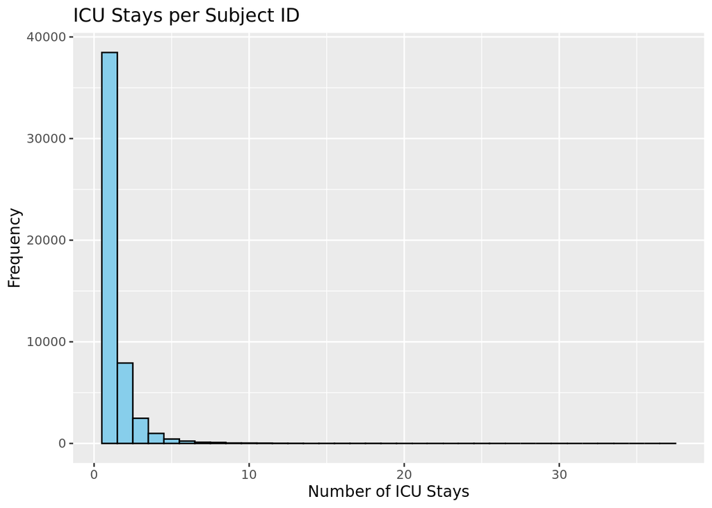

```r
unique_subject_ids <- icustays_tble %>%
  distinct(subject_id) %>%
  nrow()

# Summarize the number of ICU stays per subject_id using graphs
icu_stay_summary <- icustays_tble %>%
  group_by(subject_id) %>%
  summarise(num_stays = n())

# Create a histogram of the number of ICU stays per subject_id
ggplot(icu_stay_summary, aes(x = num_stays)) +
  geom_histogram(binwidth = 1, fill = "skyblue", color = "black") +
  labs(x = "Number of ICU Stays", y = "Frequency", title = "ICU Stays per Subject ID")
```

## Q3. `admissions` data

Information of the patients admitted into hospital is available in `admissions.csv.gz`. See https://mimic.mit.edu/docs/iv/modules/hosp/admissions/ for details of each field in this file. The first 10 lines are

```bash
zcat < ~/mimic/hosp/admissions.csv.gz | head
```

```
subject_id,hadm_id,admittime,dischtime,deathtime,admission_type,admit_provider_id,admission_location,discharge_location,insurance,language,marital_status,race,edregtime,edouttime,hospital_expire_flag
10000032,22595853,2180-05-06 22:23:00,2180-05-07 17:15:00,,URGENT,P874LG,TRANSFER FROM HOSPITAL,HOME,Other,ENGLISH,WIDOWED,WHITE,2180-05-06 19:17:00,2180-05-06 23:30:00,0
10000032,22841357,2180-06-26 18:27:00,2180-06-27 18:49:00,,EW EMER.,P09Q6Y,EMERGENCY ROOM,HOME,Medicaid,ENGLISH,WIDOWED,WHITE,2180-06-26 15:54:00,2180-06-26 21:31:00,0
10000032,25742920,2180-08-05 23:44:00,2180-08-07 17:50:00,,EW EMER.,P60CC5,EMERGENCY ROOM,HOSPICE,Medicaid,ENGLISH,WIDOWED,WHITE,2180-08-05 20:58:00,2180-08-06 01:44:00,0
10000032,29079034,2180-07-23 12:35:00,2180-07-25 17:55:00,,EW EMER.,P30KEH,EMERGENCY ROOM,HOME,Medicaid,ENGLISH,WIDOWED,WHITE,2180-07-23 05:54:00,2180-07-23 14:00:00,0
10000068,25022803,2160-03-03 23:16:00,2160-03-04 06:26:00,,EU OBSERVATION,P51VDL,EMERGENCY ROOM,,Other,ENGLISH,SINGLE,WHITE,2160-03-03 21:55:00,2160-03-04 06:26:00,0
10000084,23052089,2160-11-21 01:56:00,2160-11-25 14:52:00,,EW EMER.,P6957U,WALK-IN/SELF REFERRAL,HOME HEALTH CARE,Medicare,ENGLISH,MARRIED,WHITE,2160-11-20 20:36:00,2160-11-21 03:20:00,0
10000084,29888819,2160-12-28 05:11:00,2160-12-28 16:07:00,,EU OBSERVATION,P63AD6,PHYSICIAN REFERRAL,,Medicare,ENGLISH,MARRIED,WHITE,2160-12-27 18:32:00,2160-12-28 16:07:00,0
10000108,27250926,2163-09-27 23:17:00,2163-09-28 09:04:00,,EU OBSERVATION,P38XXV,EMERGENCY ROOM,,Other,ENGLISH,SINGLE,WHITE,2163-09-27 16:18:00,2163-09-28 09:04:00,0
10000117,22927623,2181-11-15 02:05:00,2181-11-15 14:52:00,,EU OBSERVATION,P2358X,EMERGENCY ROOM,,Other,ENGLISH,DIVORCED,WHITE,2181-11-14 21:51:00,2181-11-15 09:57:00,0
```

### Q3.1 Ingestion

Import `admissions.csv.gz` as a tibble `admissions_tble`.

**Answer:**

```r
admissions_tble <- read_csv("~/mimic/hosp/admissions.csv.gz")
class(admissions_tble)
```

```
[1] "spec_tbl_df" "tbl_df"      "tbl"         "data.frame"
```

### Q3.2 Summary and visualization

Summarize the following information by graphics and explain any patterns you see.

- number of admissions per patient
- admission hour (anything unusual?)
- admission minute (anything unusual?)
- length of hospital stay (from admission to discharge) (anything unusual?)

According to the [MIMIC-IV documentation](https://mimic.mit.edu/docs/iv/about/concepts/#date-shifting),

> All dates in the database have been shifted to protect patient confidentiality. Dates will be internally consistent for the same patient, but randomly distributed in the future. Dates of birth which occur in the present time are not true dates of birth. Furthermore, dates of birth which occur before the year 1900 occur if the patient is older than 89. In these cases, the patient’s age at their first admission has been fixed to 300.

**Answer:**

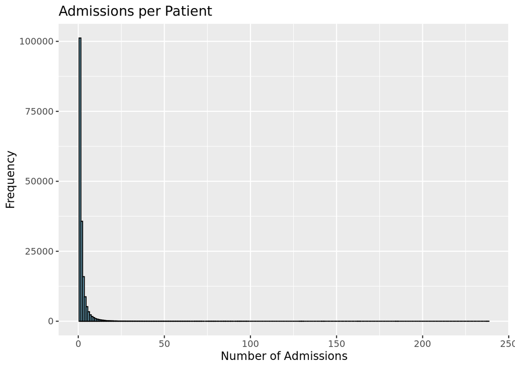

```r
# Summarize the number of admissions per patient
num_admissions <- admissions_tble %>%
  group_by(subject_id) %>%
  summarise(num_admissions = n())

# Create a histogram of the number of admissions per patient
ggplot(num_admissions, aes(x = num_admissions)) +
  geom_histogram(binwidth = 1, fill = "skyblue", color = "black") +
  labs(x = "Number of Admissions", y = "Frequency", title = "Admissions per Patient")
```

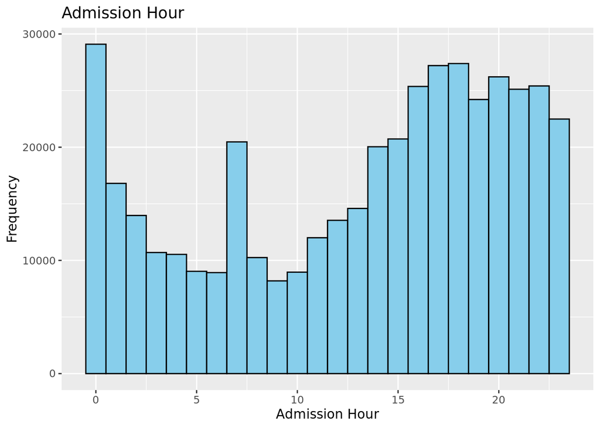

```r
# Create a histogram of the admission hour
ggplot(admissions_tble, aes(x = hour(admittime))) +
  geom_histogram(binwidth = 1, fill = "skyblue", color = "black") +
  labs(x = "Admission Hour", y = "Frequency", title = "Admission Hour")
```

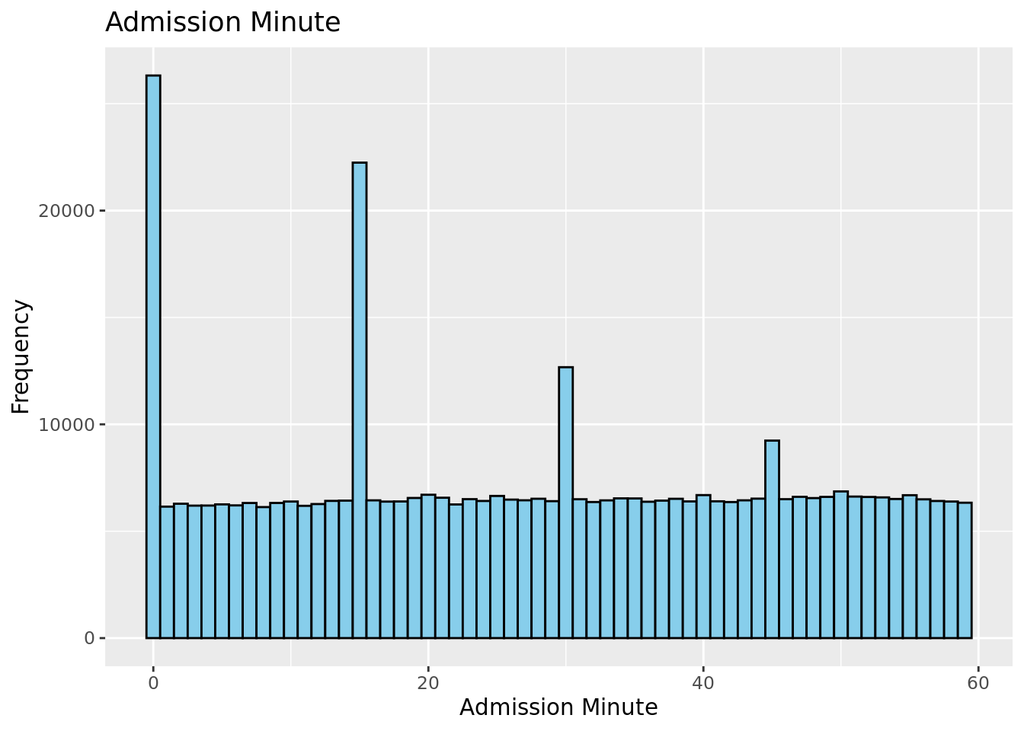

```r
# Create a histogram of the admission minute
ggplot(admissions_tble, aes(x = minute(admittime))) +
  geom_histogram(binwidth = 1, fill = "skyblue", color = "black") +
  labs(x = "Admission Minute", y = "Frequency", title = "Admission Minute")
```

```
Defaulting to continuous.
```

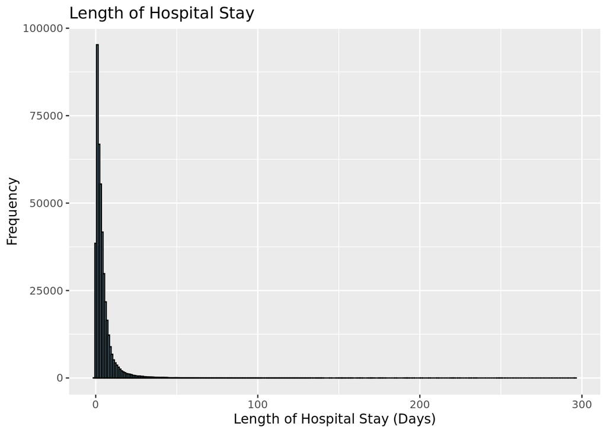

```r
# Create a histogram of the length of hospital stay
admissions_tble <- admissions_tble %>%
  mutate(length_of_stay = difftime(dischtime, admittime, units = "days"))

ggplot(admissions_tble, aes(x = length_of_stay)) +
  geom_histogram(binwidth = 1, fill = "skyblue", color = "black") +
  labs(x = "Length of Hospital Stay (Days)", y = "Frequency", title = "Length of Hospital Stay")
```

Most people 1 have 1 admission, and the admission hour mainly in the night and in 0 o’clock, 7 o’clock. The admission minute is mainly in 0, 15, 30, 45 minute. The interval is fifteen minutes. And the length of hospital stay is mainly in 0-10 days.

## Q4. `patients` data

Patient information is available in `patients.csv.gz`. See https://mimic.mit.edu/docs/iv/modules/hosp/patients/ for details of each field in this file. The first 10 lines are

```bash
zcat < ~/mimic/hosp/patients.csv.gz | head
```

```
subject_id,gender,anchor_age,anchor_year,anchor_year_group,dod
10000032,F,52,2180,2014 - 2016,2180-09-09
10000048,F,23,2126,2008 - 2010,
10000068,F,19,2160,2008 - 2010,
10000084,M,72,2160,2017 - 2019,2161-02-13
10000102,F,27,2136,2008 - 2010,
10000108,M,25,2163,2014 - 2016,
10000115,M,24,2154,2017 - 2019,
10000117,F,48,2174,2008 - 2010,
10000178,F,59,2157,2017 - 2019,
```

### Q4.1 Ingestion

Import `patients.csv.gz` (https://mimic.mit.edu/docs/iv/modules/hosp/patients/) as a tibble `patients_tble`.

**Answer:**

```r
patients_tble <- read_csv("~/mimic/hosp/patients.csv.gz")
class(patients_tble)
```

```
[1] "spec_tbl_df" "tbl_df"      "tbl"         "data.frame"
```

### Q4.2 Summary and visualization

Summarize variables `gender` and `anchor_age` by graphics, and explain any patterns you see.

**Answer:**

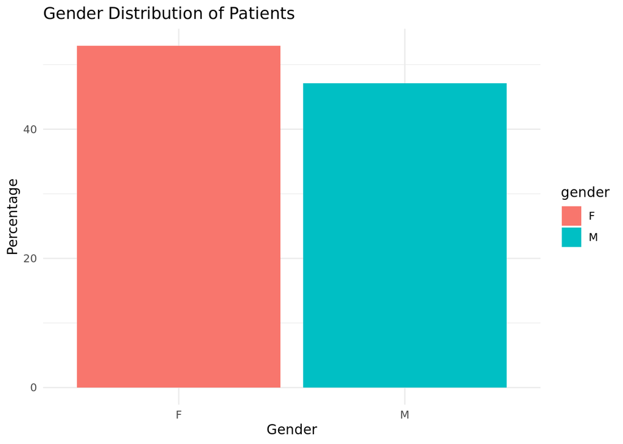

```r
gender_summary <- patients_tble %>%
  count(gender) %>%
  mutate(percent = n / sum(n) * 100)

ggplot(gender_summary, aes(x = gender, y = percent, fill = gender)) +
  geom_bar(stat = "identity") +
  labs(title = "Gender Distribution of Patients",
       x = "Gender",
       y = "Percentage") +
  theme_minimal()
```

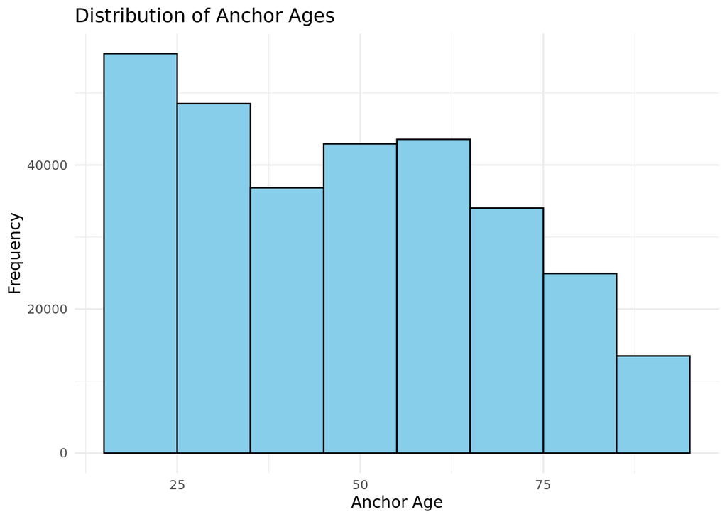

```r
anchor_age_summary <- patients_tble %>%
  ggplot(aes(x = anchor_age)) +
  geom_histogram(binwidth = 10, fill = "skyblue", color = "black") +
  labs(title = "Distribution of Anchor Ages",
       x = "Anchor Age",
       y = "Frequency") +
  theme_minimal()

print(anchor_age_summary)
```

## Q5. Lab results

`labevents.csv.gz` (https://mimic.mit.edu/docs/iv/modules/hosp/labevents/) contains all laboratory measurements for patients. The first 10 lines are

```bash
zcat < ~/mimic/hosp/labevents.csv.gz | head
```

[output not shown]

`d_labitems.csv.gz` (https://mimic.mit.edu/docs/iv/modules/hosp/d_labitems/) is the dictionary of lab measurements.

```bash
zcat < ~/mimic/hosp/d_labitems.csv.gz | head
```

```
itemid,label,fluid,category
50801,Alveolar-arterial Gradient,Blood,Blood Gas
50802,Base Excess,Blood,Blood Gas
50803,"Calculated Bicarbonate, Whole Blood",Blood,Blood Gas
50804,Calculated Total CO2,Blood,Blood Gas
50805,Carboxyhemoglobin,Blood,Blood Gas
50806,"Chloride, Whole Blood",Blood,Blood Gas
50808,Free Calcium,Blood,Blood Gas
50809,Glucose,Blood,Blood Gas
50810,"Hematocrit, Calculated",Blood,Blood Gas
```

We are interested in the lab measurements of creatinine (50912), potassium (50971), sodium (50983), chloride (50902), bicarbonate (50882), hematocrit (51221), white blood cell count (51301), and glucose (50931). Retrieve a subset of `labevents.csv.gz` that only containing these items for the patients in `icustays_tble`. Further restrict to the last available measurement (by `storetime`) before the ICU stay. The final `labevents_tble` should have one row per ICU stay and columns for each lab measurement.

[figure not shown]

Hint: Use the Parquet format you generated in Homework 2. For reproducibility, make `labevents_pq` folder available at the current working directory `hw3`, for example, by a symbolic link.

**Answer:**

```r
library(tidyverse)

# Read d_labitems data
d_labitems <- read_csv("~/mimic/hosp/d_labitems.csv.gz",
                        col_types = cols(
                          label = col_character(),
                          fluid = col_character(),
                          category = col_character(),
                          itemid = col_double())) %>%
  print(width = Inf)
```

```
# A tibble: 1,622 × 4
   itemid label                               fluid category
    <dbl> <chr>                               <chr> <chr>
 1  50801 Alveolar-arterial Gradient          Blood Blood Gas
 2  50802 Base Excess                         Blood Blood Gas
 3  50803 Calculated Bicarbonate, Whole Blood Blood Blood Gas
 4  50804 Calculated Total CO2                Blood Blood Gas
 5  50805 Carboxyhemoglobin                   Blood Blood Gas
 6  50806 Chloride, Whole Blood               Blood Blood Gas
 7  50808 Free Calcium                        Blood Blood Gas
 8  50809 Glucose                             Blood Blood Gas
 9  50810 Hematocrit, Calculated              Blood Blood Gas
10  50811 Hemoglobin                          Blood Blood Gas
# ℹ 1,612 more rows
```

```r
icustays_tble <- icustays_tble %>%
  mutate(subject_id = as.character(subject_id))

labevents <- read_parquet("~/labevents.parquet/part-0.parquet")

# Read the lab events data and perform a series of transformations
labevents_tble <- labevents %>%
  select(subject_id, itemid, valuenum, storetime) %>%
  mutate(
    subject_id = as.character(subject_id),
    itemid = as.numeric(itemid)
  ) %>%
  filter(subject_id %in% icustays_tble$subject_id) %>%
  filter(itemid %in% c(50912, 50971, 50983, 50902,
                       50882, 51221, 51301, 50931)) %>%
  collect() %>%
  left_join(icustays_tble, by = "subject_id") %>%
  left_join(d_labitems, by = "itemid") %>%
  select(subject_id, stay_id, label, valuenum, storetime, intime) %>%
  filter(storetime < intime) %>%
  group_by(subject_id, stay_id, label) %>%
  slice_max(order_by = storetime, n = 1) %>%
  ungroup() %>%
  pivot_wider(
    names_from = label,
    values_from = valuenum,
    values_fn = list(valuenum = last)
  )
# Print the resulting labevents table
print(labevents_tble)
```

```
# A tibble: 158,108 × 12
   subject_id  stay_id storetime           intime              Bicarbonate
   <chr>         <dbl> <dttm>              <dttm>                    <dbl>
 1 10000032   39553978 2180-07-23 07:59:00 2180-07-23 14:00:00          25
 2 10000032   39553978 2180-07-23 07:00:00 2180-07-23 14:00:00          NA
 3 10000032   39553978 2180-07-23 08:14:00 2180-07-23 14:00:00          NA
 4 10000980   39765666 2189-06-27 07:56:00 2189-06-27 08:42:00          21
 5 10000980   39765666 2189-06-27 07:06:00 2189-06-27 08:42:00          NA
 6 10001217   34592300 2157-12-19 08:17:00 2157-12-19 15:42:24          30
 7 10001217   34592300 2157-12-19 07:48:00 2157-12-19 15:42:24          NA
 8 10001217   37067082 2157-11-20 14:13:00 2157-11-20 19:18:02          22
 9 10001217   37067082 2157-11-20 13:49:00 2157-11-20 19:18:02          NA
10 10001725   31205490 2110-04-08 17:49:00 2110-04-11 15:52:22          NA
# ℹ 158,098 more rows
# ℹ 7 more variables: Chloride <dbl>, Creatinine <dbl>, Glucose <dbl>,
#   Hematocrit <dbl>, Potassium <dbl>, Sodium <dbl>, `White Blood Cells` <dbl>
```

## Q6. Vitals from charted events

`chartevents.csv.gz` (https://mimic.mit.edu/docs/iv/modules/icu/chartevents/) contains all the charted data available for a patient. During their ICU stay, the primary repository of a patient’s information is their electronic chart. The `itemid` variable indicates a single measurement type in the database. The `value` variable is the value measured for `itemid`. The first 10 lines of `chartevents.csv.gz` are

```bash
zcat < ~/mimic/icu/chartevents.csv.gz | head
```

[output not shown]

`d_items.csv.gz` (https://mimic.mit.edu/docs/iv/modules/icu/d_items/) is the dictionary for the `itemid` in `chartevents.csv.gz`.

```bash
zcat < ~/mimic/icu/d_items.csv.gz | head
```

```
itemid,label,abbreviation,linksto,category,unitname,param_type,lownormalvalue,highnormalvalue
220001,Problem List,Problem List,chartevents,General,,Text,,
220003,ICU Admission date,ICU Admission date,datetimeevents,ADT,,Date and time,,
220045,Heart Rate,HR,chartevents,Routine Vital Signs,bpm,Numeric,,
220046,Heart rate Alarm - High,HR Alarm - High,chartevents,Alarms,bpm,Numeric,,
220047,Heart Rate Alarm - Low,HR Alarm - Low,chartevents,Alarms,bpm,Numeric,,
220048,Heart Rhythm,Heart Rhythm,chartevents,Routine Vital Signs,,Text,,
220050,Arterial Blood Pressure systolic,ABPs,chartevents,Routine Vital Signs,mmHg,Numeric,90,140
220051,Arterial Blood Pressure diastolic,ABPd,chartevents,Routine Vital Signs,mmHg,Numeric,60,90
220052,Arterial Blood Pressure mean,ABPm,chartevents,Routine Vital Signs,mmHg,Numeric,,
```

We are interested in the vitals for ICU patients: heart rate (220045), systolic non-invasive blood pressure (220179), diastolic non-invasive blood pressure (220180), body temperature in Fahrenheit (223761), and respiratory rate (220210). Retrieve a subset of `chartevents.csv.gz` only containing these items for the patients in `icustays_tble`. Further restrict to the first vital measurement within the ICU stay. The final `chartevents_tble` should have one row per ICU stay and columns for each vital measurement.

[figure not shown]

Hint: Use the Parquet format you generated in Homework 2. For reproducibility, make `chartevents_pq` folder available at the current working directory, for example, by a symbolic link.

**Amswer:**

```r
library(dplyr)
library(tidyr)

# Read the d_items.csv.gz file
d_items <- read_csv("~/mimic/icu/d_items.csv.gz")
# Specify vital signs itemids
vitals <- c(220045, 220179, 220180, 223761, 220210)

# Load chartevents data from Parquet (more efficient for large datasets)
chartevents_tble <- arrow::open_dataset("~/chartevents.parquet", format = "parquet") %>%
  filter(itemid %in% vitals) %>%
  collect()

# Ensure subject_id is of the same type in both datasets
icustays_tble <- icustays_tble %>%
  mutate(subject_id = as.character(subject_id))

chartevents_tble <- chartevents_tble %>%
  mutate(subject_id = as.character(subject_id))

# Join chartevents with icustays
chartevents_icustays <- chartevents_tble %>%
  inner_join(icustays_tble, by = c("subject_id", "hadm_id", "stay_id")) %>%
  filter(charttime >= intime & charttime <= outtime)

# Select the first measurement within ICU stay
chartevents_first_meas <- chartevents_icustays %>%
  group_by(subject_id, stay_id, itemid) %>%
  summarise(value = first(value, order_by = charttime), .groups = "drop")

# Pivot to the required format
chartevents_final_tble <- chartevents_first_meas %>%
  pivot_wider(
    id_cols = c(subject_id, stay_id),
    names_from = itemid,
    values_from = value,
    names_prefix = "vital_"
  )%>%
  rename(
    heart_rate = vital_220045,
    systolic_blood_pressure = vital_220179,
    diastolic_blood_pressure = vital_220180,
    body_temperature_Fahrenheit = vital_223761,
    respiratory_rate = vital_220210
  )

print(chartevents_final_tble)
```

```
# A tibble: 73,164 × 7
   subject_id  stay_id heart_rate systolic_blood_pressure diastolic_blood_pres…¹
   <chr>         <dbl> <chr>      <chr>                   <chr>
 1 10000032   39553978 94         82                      59
 2 10000980   39765666 77         150                     77
 3 10001217   34592300 79         121                     72
 4 10001217   37067082 101        145                     84
 5 10001725   31205490 82         114                     65
 6 10001884   37510196 69         122                     67
 7 10002013   39060235 103        104                     70
 8 10002155   31090461 70         103                     57
 9 10002155   32358465 98         109                     65
10 10002155   33685454 75         118                     56
# ℹ 73,154 more rows
# ℹ abbreviated name: ¹diastolic_blood_pressure
# ℹ 2 more variables: respiratory_rate <chr>, body_temperature_Fahrenheit <chr>
```

## Q7. Putting things together

Let us create a tibble `mimic_icu_cohort` for all ICU stays, where rows are all ICU stays of adults (age at `intime` >= 18) and columns contain at least following variables

- all variables in `icustays_tble`
- all variables in `admissions_tble`
- all variables in `patients_tble`
- the last lab measurements before the ICU stay in `labevents_tble`
- the first vital measurements during the ICU stay in `chartevents_tble`

The final `mimic_icu_cohort` should have one row per ICU stay and columns for each variable.

[figure not shown]

```r
library(dplyr)
library(readr)

labevents_tble <- labevents_tble%>%
  as_tibble()%>%
  mutate(subject_id = as.character(subject_id))

# Read and convert admissions data into a tibble
admissions_tble <- read_csv("~/mimic/hosp/admissions.csv.gz") %>%
  as_tibble()%>%
  mutate(subject_id = as.character(subject_id))
# Read and convert patients data into a tibble
patients_tble <- read_csv("~/mimic/hosp/patients.csv.gz") %>%
  as_tibble()%>%
  mutate(subject_id = as.character(subject_id))
chartevents_final_tble <- chartevents_final_tble %>%
  mutate(subject_id = as.character(subject_id))


# Inner join icustays_tble with patients_tble
mimic_icu_cohort <- icustays_tble %>%
  inner_join(patients_tble, by = "subject_id") %>%
  mutate(age_intime = year(intime) - anchor_year + anchor_age) %>%
  filter(age_intime >= 18) %>%
  inner_join(admissions_tble, by = c("subject_id", "hadm_id")) %>%
  left_join(labevents_tble%>% group_by(subject_id), by = "subject_id") %>%
  left_join(chartevents_final_tble %>% group_by(subject_id), by = "subject_id")
# Print summary of mimic_icu_cohort
glimpse(mimic_icu_cohort)
```

```
Rows: 2,370,624
Columns: 45
$ subject_id                  <chr> "10000032", "10000032", "10000032", "10000…
$ hadm_id                     <dbl> 29079034, 29079034, 29079034, 26913865, 26…
$ stay_id.x                   <dbl> 39553978, 39553978, 39553978, 39765666, 39…
$ first_careunit              <chr> "Medical Intensive Care Unit (MICU)", "Med…
$ last_careunit               <chr> "Medical Intensive Care Unit (MICU)", "Med…
$ intime.x                    <dttm> 2180-07-23 14:00:00, 2180-07-23 14:00:00,…
$ outtime                     <dttm> 2180-07-23 23:50:47, 2180-07-23 23:50:47,…
$ los                         <dbl> 0.4102662, 0.4102662, 0.4102662, 0.4975347…
$ gender                      <chr> "F", "F", "F", "F", "F", "F", "F", "F", "F…
$ anchor_age                  <dbl> 52, 52, 52, 73, 73, 55, 55, 55, 55, 55, 55…
$ anchor_year                 <dbl> 2180, 2180, 2180, 2186, 2186, 2157, 2157, …
$ anchor_year_group           <chr> "2014 - 2016", "2014 - 2016", "2014 - 2016…
$ dod                         <date> 2180-09-09, 2180-09-09, 2180-09-09, 2193-…
```

[output cut: 32 more lines]

## Q8. Exploratory data analysis (EDA)

Summarize the following information about the ICU stay cohort `mimic_icu_cohort` using appropriate numerics or graphs:

- Length of ICU stay `los` vs demographic variables (race, insurance, marital_status, gender, age at intime)
- Length of ICU stay `los` vs the last available lab measurements before ICU stay
- Length of ICU stay `los` vs the average vital measurements within the first hour of ICU stay
- Length of ICU stay `los` vs first ICU unit

**Answer:**

```r
model <- lm(los ~ race + insurance + marital_status + gender + age_intime, data = mimic_icu_cohort)
summary(model)
```

```
Call:
lm(formula = los ~ race + insurance + marital_status + gender +
    age_intime, data = mimic_icu_cohort)

Residuals:
    Min      1Q  Median      3Q     Max
 -9.220  -2.143  -1.166   0.205 106.549

Coefficients:
                                                Estimate Std. Error t value
(Intercept)                                    2.8633530  0.0920251  31.115
raceASIAN                                      0.5656390  0.0995312   5.683
raceASIAN - ASIAN INDIAN                       0.0412821  0.1016049   0.406
raceASIAN - CHINESE                           -1.5872623  0.1019091 -15.575
raceASIAN - KOREAN                             1.2297491  0.3697440   3.326
raceASIAN - SOUTH EAST ASIAN                  -2.8132044  0.0935900 -30.059
raceBLACK/AFRICAN                              1.1613269  0.1034993  11.221
raceBLACK/AFRICAN AMERICAN                    -1.8293422  0.0905668 -20.199
raceBLACK/CAPE VERDEAN                        -1.0537852  0.0996575 -10.574
raceBLACK/CARIBBEAN ISLAND                     0.2310493  0.1033060   2.237
raceHISPANIC OR LATINO                        -2.6683125  0.0959524 -27.809
raceHISPANIC/LATINO - CENTRAL AMERICAN        -1.6954907  0.1975406  -8.583
raceHISPANIC/LATINO - COLUMBIAN               -1.7847692  0.1979239  -9.017
raceHISPANIC/LATINO - CUBAN                   -1.0480147  0.1629670  -6.431
raceHISPANIC/LATINO - DOMINICAN               -0.9358033  0.0966750  -9.680
raceHISPANIC/LATINO - GUATEMALAN               0.3320212  0.1150404   2.886
raceHISPANIC/LATINO - HONDURAN                -2.0225069  0.1496606 -13.514
raceHISPANIC/LATINO - MEXICAN                 -2.6383640  0.2336399 -11.292
raceHISPANIC/LATINO - PUERTO RICAN            -1.9922451  0.0936065 -21.283
raceHISPANIC/LATINO - SALVADORAN              -2.3800623  0.1185685 -20.073
raceMULTIPLE RACE/ETHNICITY                   -1.5419461  0.1647061  -9.362
raceNATIVE HAWAIIAN OR OTHER PACIFIC ISLANDER -1.7653208  0.1861215  -9.485
raceOTHER                                     -1.1064968  0.0932531 -11.866
racePATIENT DECLINED TO ANSWER                -1.3399638  0.1221839 -10.967
racePORTUGUESE                                -1.1339107  0.0985493 -11.506
raceSOUTH AMERICAN                            -1.7200085  0.1382173 -12.444
raceUNABLE TO OBTAIN                           3.7919053  0.1115373  33.997
raceUNKNOWN                                   -0.5942525  0.0977788  -6.078
raceWHITE                                     -1.2606718  0.0903722 -13.950
raceWHITE - BRAZILIAN                         -1.0528106  0.1302661  -8.082
```

[output cut: 43 more lines]

```
raceWHITE - RUSSIAN                            < 2e-16 ***
insuranceMedicare                              < 2e-16 ***
insuranceOther                                 < 2e-16 ***
marital_statusMARRIED                          < 2e-16 ***
marital_statusSINGLE                           < 2e-16 ***
marital_statusWIDOWED                          < 2e-16 ***
genderM                                        < 2e-16 ***
age_intime                                     < 2e-16 ***
---
Signif. codes:  0 '***' 0.001 '**' 0.01 '*' 0.05 '.' 0.1 ' ' 1

Residual standard error: 4.89 on 2344202 degrees of freedom
  (26382 observations deleted due to missingness)
Multiple R-squared:  0.02824,   Adjusted R-squared:  0.02822
F-statistic:  1747 on 39 and 2344202 DF,  p-value: < 2.2e-16
```

```r
# Fit a linear regression model
model2 <- lm(los ~ Bicarbonate + Chloride + Hematocrit + Potassium +Potassium + `White Blood Cells`, data = mimic_icu_cohort)

# Summarize the regression results
summary(model2)
```

```
Call:
lm(formula = los ~ Bicarbonate + Chloride + Hematocrit + Potassium +
    Potassium + `White Blood Cells`, data = mimic_icu_cohort)

Residuals:
   Min     1Q Median     3Q    Max
-5.285 -2.170 -0.983  0.384 85.720

Coefficients:
                     Estimate Std. Error t value Pr(>|t|)
(Intercept)         10.473057   3.381629   3.097 0.001985 **
Bicarbonate          0.118918   0.035453   3.354 0.000812 ***
Chloride            -0.073884   0.024959  -2.960 0.003115 **
Hematocrit          -0.161100   0.019097  -8.436  < 2e-16 ***
Potassium            0.611455   0.256492   2.384 0.017232 *
`White Blood Cells` -0.008629   0.005354  -1.612 0.107195
---
Signif. codes:  0 '***' 0.001 '**' 0.01 '*' 0.05 '.' 0.1 ' ' 1

Residual standard error: 5.781 on 1808 degrees of freedom
  (2368810 observations deleted due to missingness)
Multiple R-squared:  0.05843,   Adjusted R-squared:  0.05583
F-statistic: 22.44 on 5 and 1808 DF,  p-value: < 2.2e-16
```

```r
vars_to_convert <- c("heart_rate", "systolic_blood_pressure", "diastolic_blood_pressure", "body_temperature_Fahrenheit", "respiratory_rate")

for (var in vars_to_convert) {
  mimic_icu_cohort[[var]] <- as.numeric(mimic_icu_cohort[[var]])
}

mimic_icu_cohort$mean_vital_signs <- rowMeans(mimic_icu_cohort[, c("heart_rate", "systolic_blood_pressure", "diastolic_blood_pressure", "body_temperature_Fahrenheit", "respiratory_rate")])

model3 <- lm(los ~ mean_vital_signs, data = mimic_icu_cohort)

# Summarize the regression results
summary(model3)
```

```
Call:
lm(formula = los ~ mean_vital_signs, data = mimic_icu_cohort)

Residuals:
    Min      1Q  Median      3Q     Max
 -3.506  -2.244  -1.397   0.177 106.923

Coefficients:
                   Estimate Std. Error t value Pr(>|t|)
(Intercept)       4.0941804  0.0144637  283.07   <2e-16 ***
mean_vital_signs -0.0097108  0.0001768  -54.92   <2e-16 ***
---
Signif. codes:  0 '***' 0.001 '**' 0.01 '*' 0.05 '.' 0.1 ' ' 1

Residual standard error: 4.955 on 2330376 degrees of freedom
  (40246 observations deleted due to missingness)
Multiple R-squared:  0.001292,  Adjusted R-squared:  0.001292
F-statistic:  3016 on 1 and 2330376 DF,  p-value: < 2.2e-16
```

```r
# Conduct ANOVA
anova_result <- aov(los ~ first_careunit, data = mimic_icu_cohort)

# Summary of ANOVA results
summary(anova_result)
```

```
                    Df   Sum Sq Mean Sq F value Pr(>F)
first_careunit       8  1008722  126090    5191 <2e-16 ***
Residuals      2370615 57586272      24
---
Signif. codes:  0 '***' 0.001 '**' 0.01 '*' 0.05 '.' 0.1 ' ' 1
```